# by MAY CHU

========================================================

# ABSTRACT

This project aims to use Exploratory Data Analysis (EDA) to explore the Prosper Loan dataset which includes over 113937 listings of Prosper borrowers.

Prosper is one of the leading online Peer-to-peer lending platform that connects potential borrowers with potential lenders, filters candidates on both sides of the equation, and sets some rules. Peer-to-peer lending is the new trend in recent years, which allows people to seek out a loan from somewhere other than a traditional banking institution. Instead of going to a bank or a credit union, borrowers can get a loan that comes from individuals looking to earn more interest on their money than promised by traditional savings accounts.

Here how it works:

- Borrowers choose a loan amount, purpose and post a loan listing.
- Investors review loan listings and invest in listings that meet their criteria.
- Once the process is complete, borrowers make fixed monthly payments and investors receive a portion of those payments directly to their Prosper account.

This project tends to answer 4 questions:

1. What is the population of Prosper borrowers?
2. What factors affect the number of investors to prosper loan?
3. What affect borrower rate and APR?
4. Loss in charge-off loans?

# Univariate Plots Section

### A. Listing summary

#### I. Loan term

```
## Source: local data frame [3 x 2]
##
##    Term     n
##   (int) (int)
## 1    12  1614
## 2    36 87778
## 3    60 24545
```

```
## [1] 0.7704082
```

There are only 3 loan terms in the dataset: 12,36,60 months. Loans with duration of 36 months (3 years) is the most popular with 87,778 observations (account for 77%).

#### II. Loan original amount

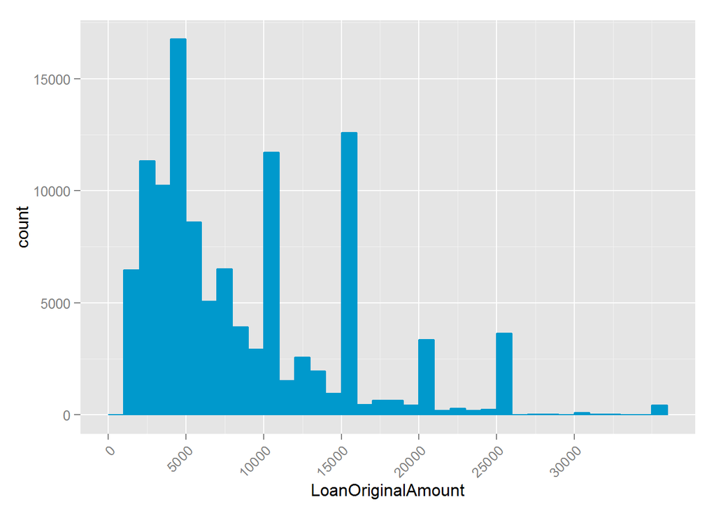

```
##    Min. 1st Qu.  Median    Mean 3rd Qu.    Max.
##    1000    4000    6500    8337   12000   35000
```

```
## [1] 430
```

```
## [1] 867
```

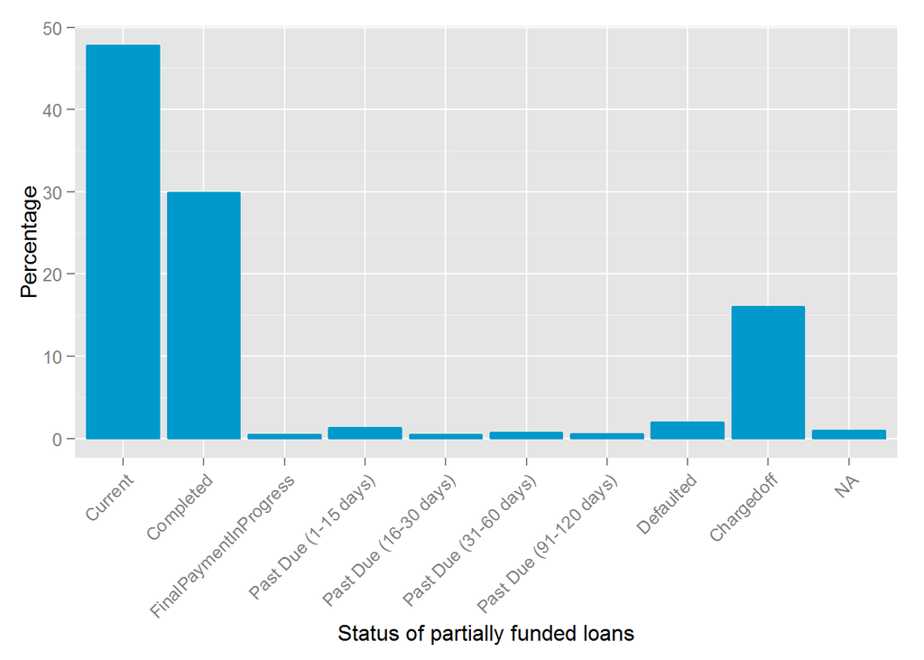

#### III. Loan purpose

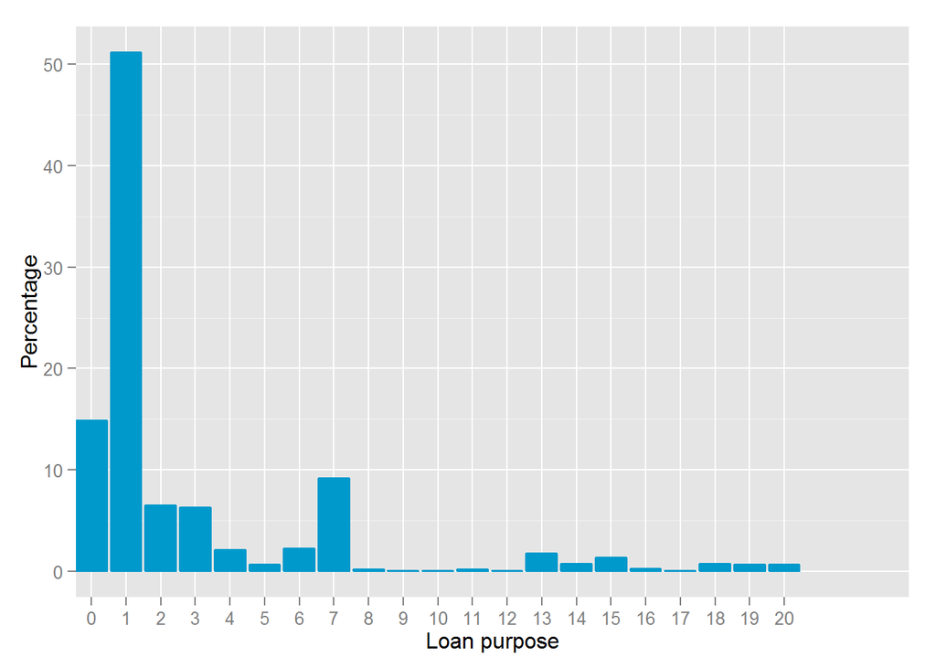

There are 20 loans purpose: 0 - Not Available, 1 - Debt Consolidation, 2 - Home Improvement, 3 - Business, 4 - Personal Loan, 5 - Student Use, 6 - Auto, 7- Other, 8 - Baby&Adoption, 9 - Boat, 10 - Cosmetic Procedure, 11 - Engagement Ring, 12 - Green Loans, 13 - Household Expenses, 14 - Large Purchases, 15 - Medical/Dental, 16 - Motorcycle, 17 - RV, 18 - Taxes, 19 - Vacation, 20 - Wedding Loans

The most common purpose is for Debt consolidation (50%), about 15% of borrowers don’t specify their purpose.

#### IV. Estimated Performance of the loan

##### 1.Prosper rating

The Prosper Rating assigned at the time the listing was created between HR (worst) - AA (best). Applicable for loans originated after July 2009. Prosper Ratings allow potential investors to easily consider a loan application’s level of risk because the rating represents an estimated average annualized loss rate range to the investor.

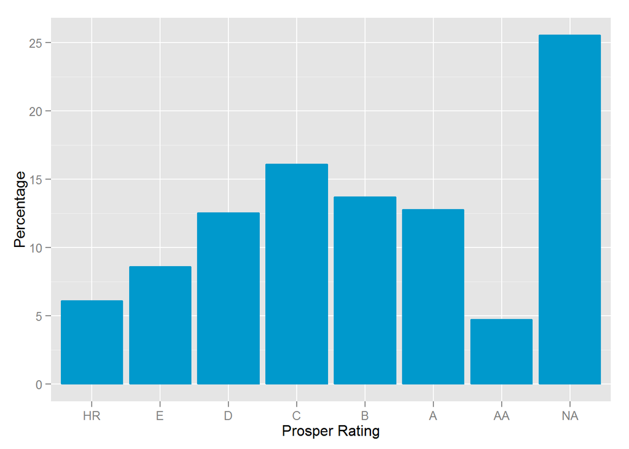

```
## Source: local data frame [8 x 2]
##
##   ProsperRating..Alpha.     n
##                  (fctr) (int)
## 1                    HR  6935
## 2                     E  9795
## 3                     D 14274
## 4                     C 18345
## 5                     B 15581
## 6                     A 14551
## 7                    AA  5372
## 8                    NA 29084
```

Prosper rating of C is the most count (represent 16%). Only 5000 borrowers have prosper rating of AA (which is the least count). 26% of the dataset (29084 listings) has blank Prosper Rating. As we know that Prosper Rating was just introduced after 2009. Before that, Prosper used the Credit Grade as the reference for borrowers’ credit. The distribution of Credit Grade is shown in the plot below.

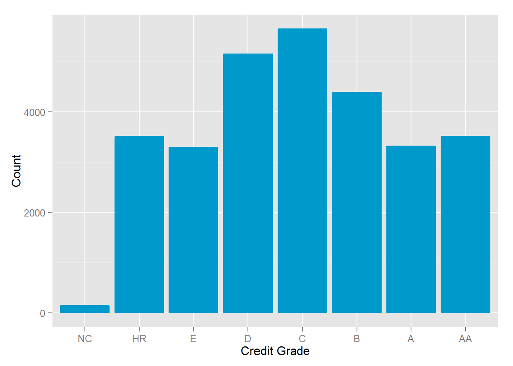

#### 2. Lender’s yield, Estimated Effective Yield, Estimated Loss and Estimated Return

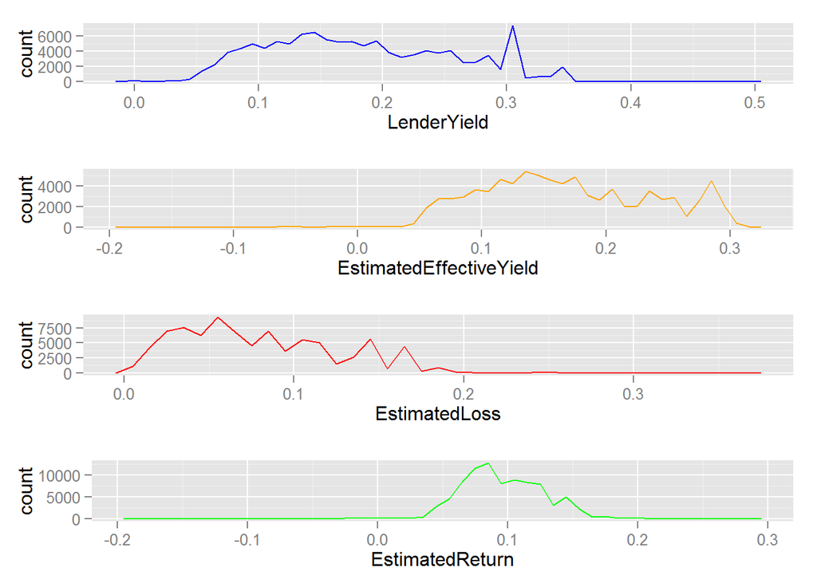

Lender yield = interest rate - servicing fee Lender yield clusters around 0.05 to 0.3 (5% - 30%)

Effective yield = borrower interest rate - the servicing fee rate - estimated uncollected interest on charge-offs + estimated collected late fees. Most Effective yield fluctuates around 0.1 to 0.3 (10%-30%)

Estimated loss is the estimated principal loss on charge-offs. Most of its values get around 0 to 0.2% (0-20%)

Estimated return = Estimated Effective Yield - Estimated Loss Rate. Estimated return value clusters around 10%

### B. Borrower’s information

#### I. Borrower’s location

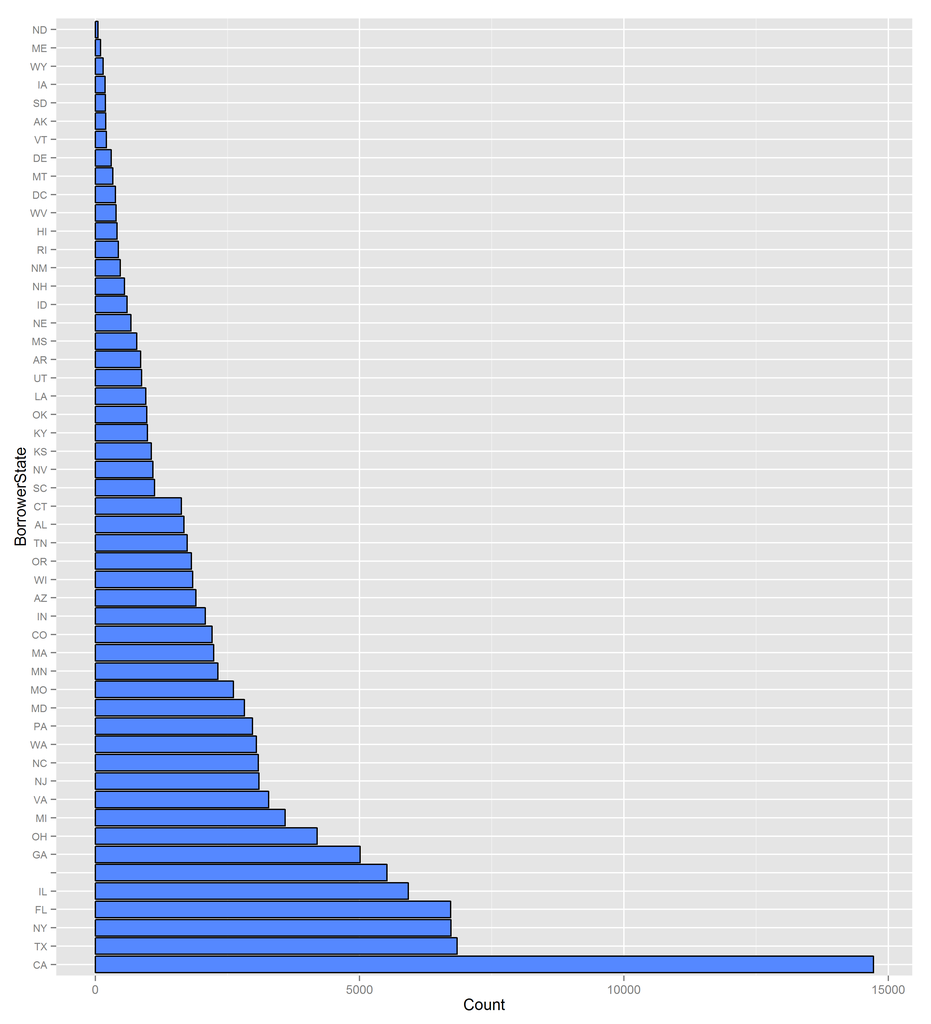

15000 borrowers come from California, which rank it the first place among borrower origin states. States of more than 5000 borrowers include: Georgia, Illinois, Florida, New York and Texas

#### II. Occupation

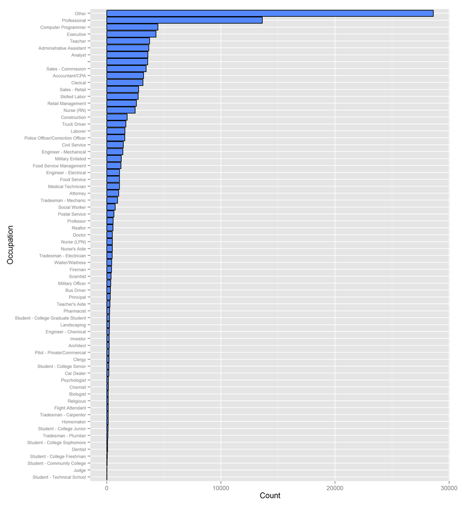

The are 68 occupations in the list. Many borowers don’t specify their occupations (with category Other). There are also missing values

##### III. Employment status

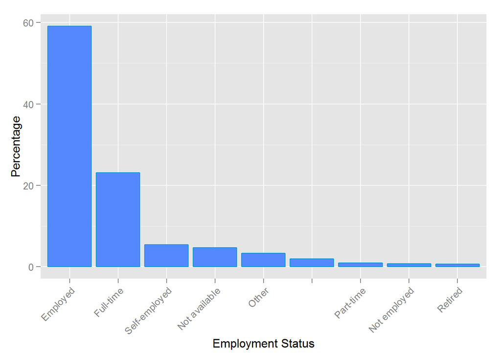

Most of the borrowers are employed (60%), work full-time(20%),part-time (2%) and self-employed (5%)… There are only 835 borrowers unemployed (very small percentage). There are missing values, Other and Not available answer which make it difficult to determine these borrowers’ employment status.

##### Employment status duration

Employment status duration is the length in months of the employment status at the time the listing was created.

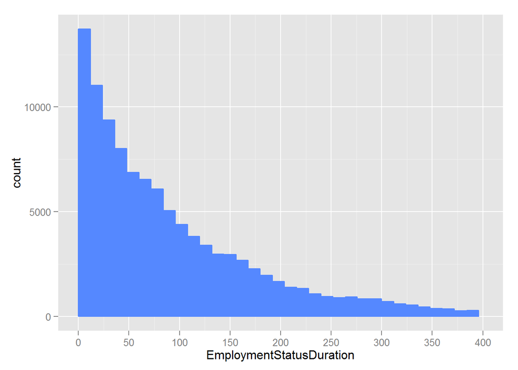

To have a more general view of employment duration, I will join the duration by years by bucket

```
##
##   (0,5]  (5,10] (10,15] (15,20] (20,25] (25,30] (30,35] (35,40]
##   48076   25624   14194    7362    4449    2715    1408     604
```

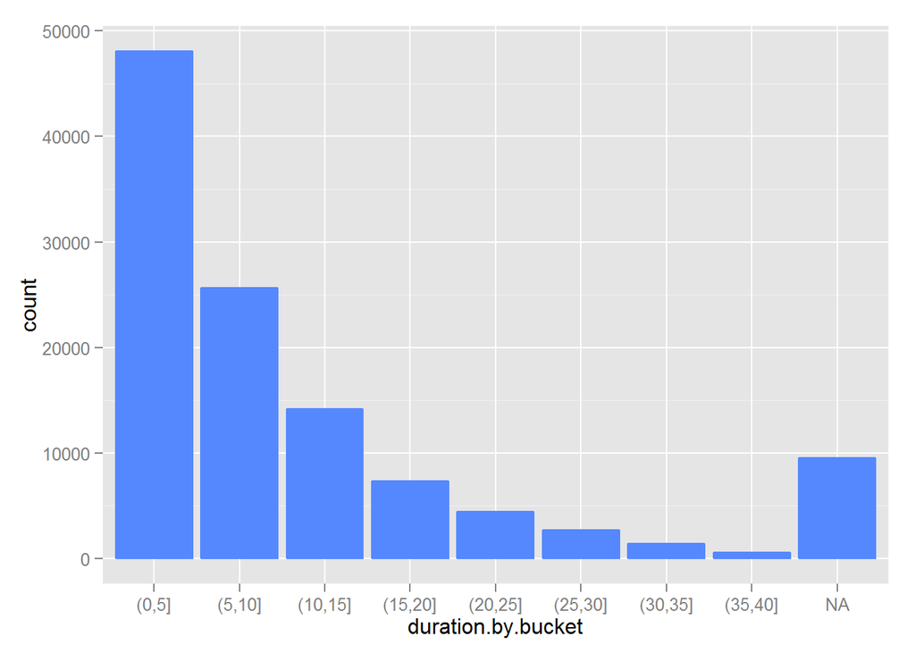

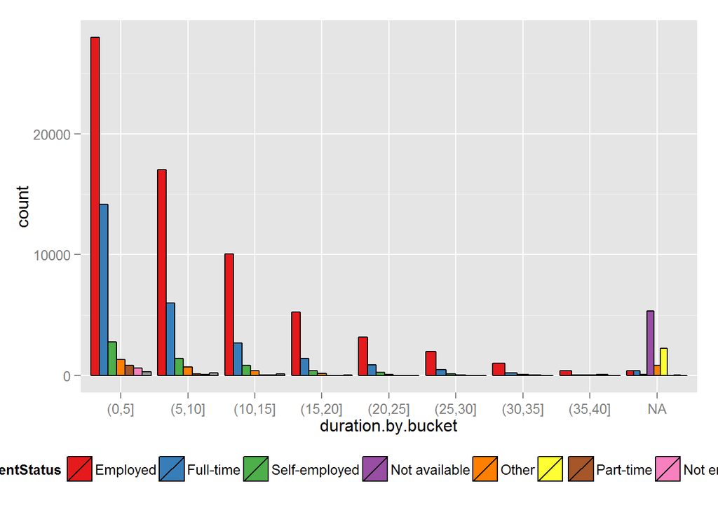

#### IV. Income Range

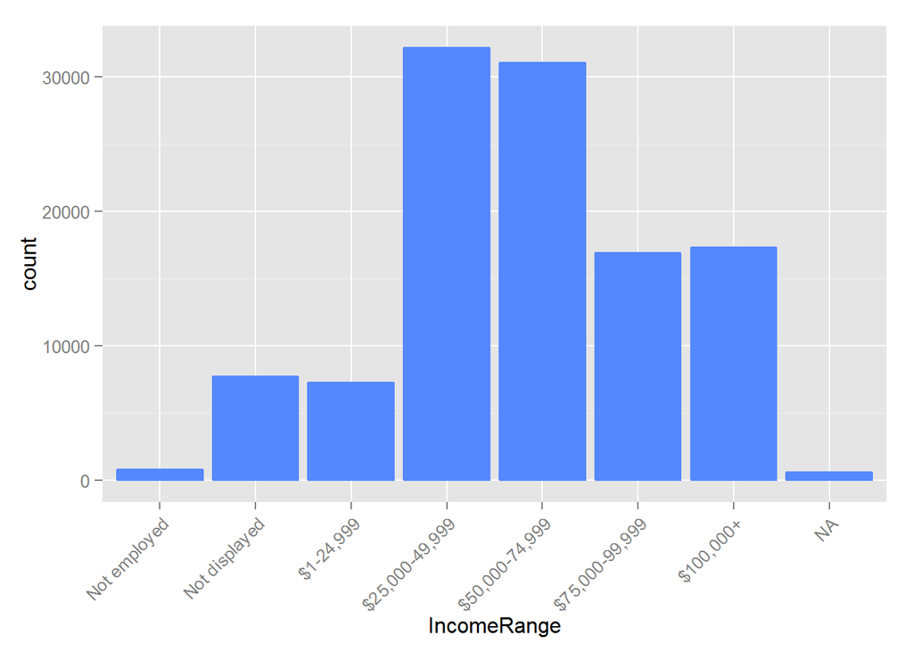

```
##   Not employed  Not displayed             $0      $1-24,999 $25,000-49,999
##            806           7741              0           7274          32192
## $50,000-74,999 $75,000-99,999      $100,000+           NA's
##          31050          16916          17337            621
```

Over 60000 borrowers earn from 25000 to 75000 annually (account for half of the dataset)

##### Income Range vs. Income Verifiable

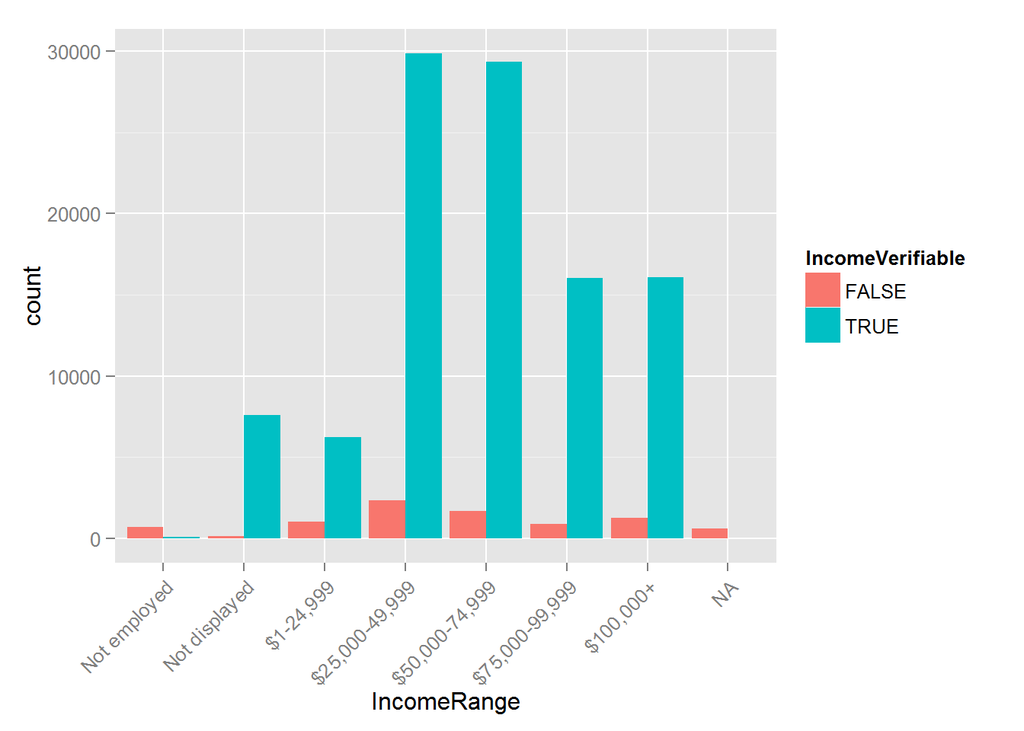

Only a very small number of borrowers cannot verify income. The only exception appears in Not-employed group, but the reason is quite obvious.

#### V. Homeownership

```
## Source: local data frame [2 x 2]
##
##   IsBorrowerHomeowner     n
##                 (lgl) (int)
## 1               FALSE 56459
## 2                TRUE 57478
```

The number of borrowers who own a house is similar to those who don’t own the house. It seems having a collateral doesn’t affect a Prosper loan listing

#### V. Borrower’s Credit Information

##### 1. Prosper Score

Prosper Score is a custom risk score built using historical Prosper data. The score ranges from 1-11, with 11 being the best, or lowest risk score. Applicable for loans originated after July 2009.

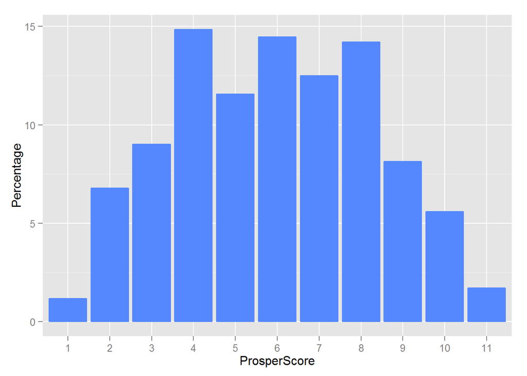

The most common Prosper Score is 4, 6, 8 (account for nearly 15% each)

##### 2.Credit Score

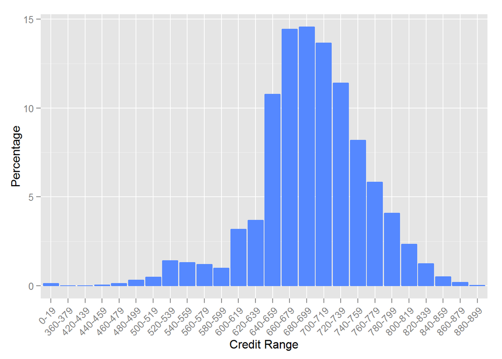

Similar to prosper rating and prosper score, many borrowers have medium credit score range from 640 to 779. Very few have scores lower than 640 or higher than 780.

##### 3.Debt/Income Ratio

The debt to income ratio of the borrower at the time the credit profile was pulled. This value is Null if the debt to income ratio is not available. This value is capped at 10.01 (any debt to income ratio larger than 1000% will be returned as 1001%).

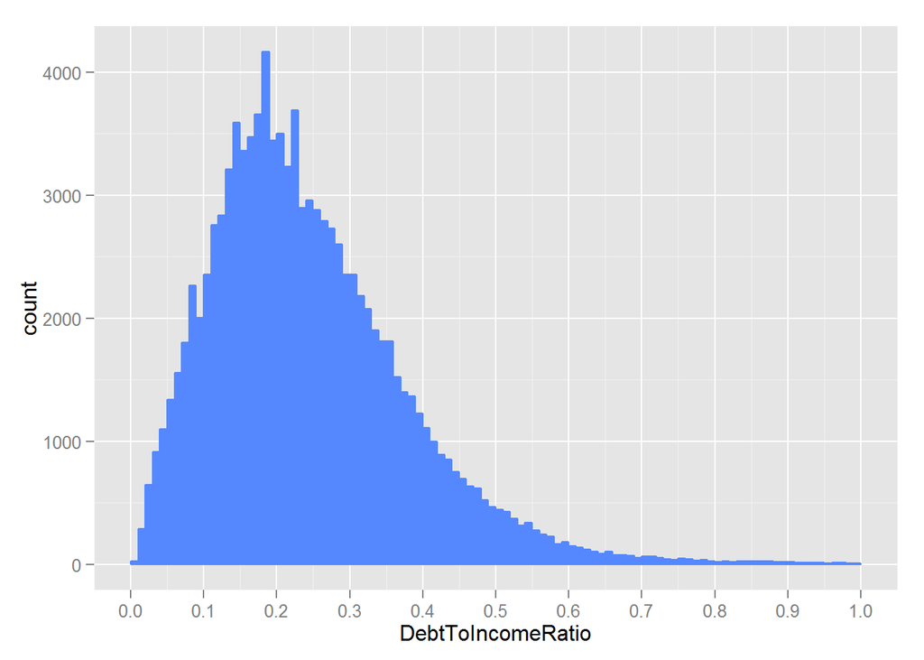

```
##    Min. 1st Qu.  Median    Mean 3rd Qu.    Max.    NA's
##   0.000   0.140   0.220   0.276   0.320  10.010    8554
```

```
## [1] 272
```

There are 272 outliers with debt/income ratio = 1001%. However, most borrowers have debt to income ratio smaller than 0.5. The most occurrence is around 0.1 to 0.25.

##### 4. Credit history

**Current Deliquencies**: Number of accounts delinquent at the time the credit profile was pulled.

```
##    Min. 1st Qu.  Median    Mean 3rd Qu.    Max.    NA's
##  0.0000  0.0000  0.0000  0.5921  0.0000 83.0000     697
```

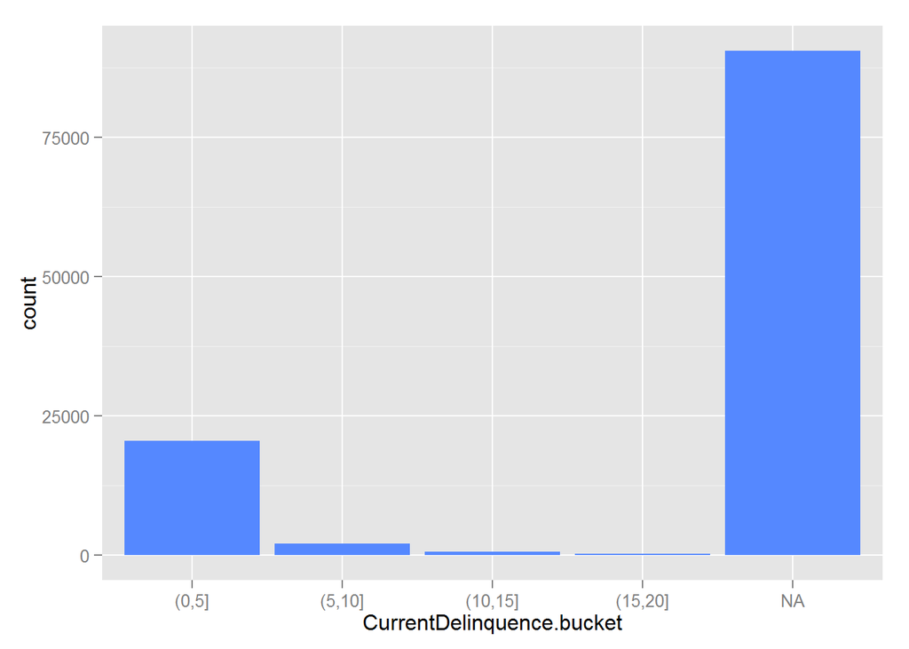

**Inquiries Last 6 Months**: Number of inquiries in the past six months at the time the credit profile was pulled. Inquiries are the number of times borrowers attempted to borrow money in the past six months

```
##    Min. 1st Qu.  Median    Mean 3rd Qu.    Max.    NA's
##   0.000   0.000   1.000   1.435   2.000 105.000     697
```

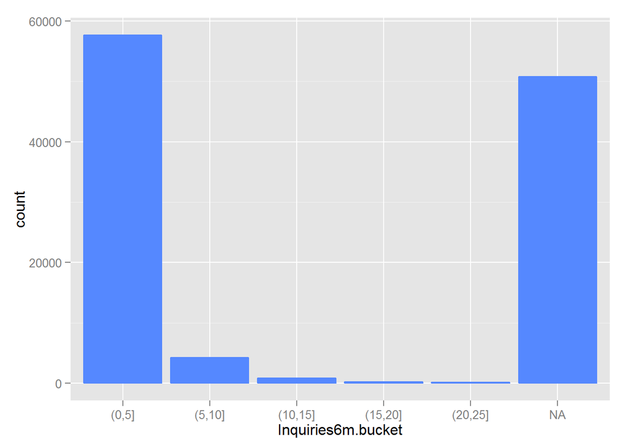

**Bank card utilization**: The percentage of available revolving credit that is utilized at the time the credit profile was pulled.

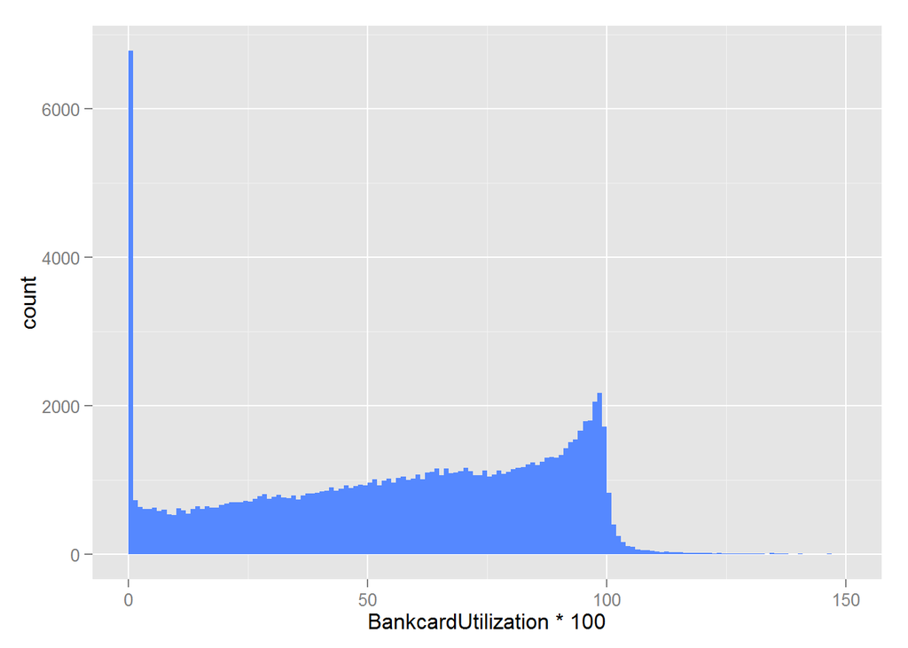

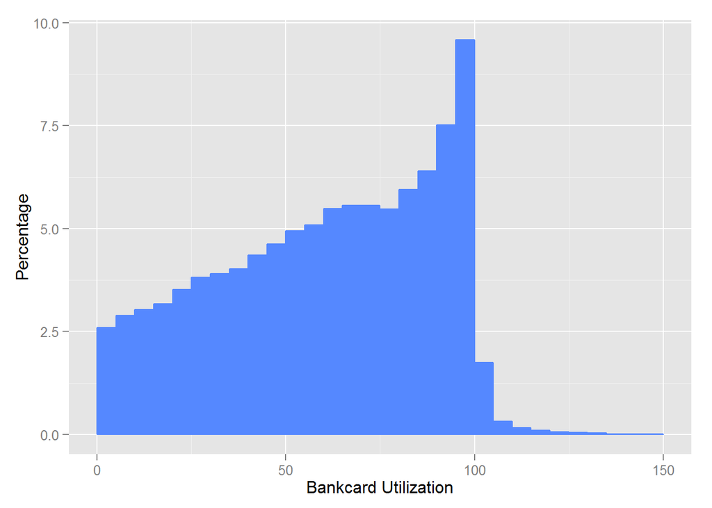

There are nearly 7000 borrowers with 0 bank card utilization. However, among 99,551 (87.4%) borrowers who use their credit cards, there are 63% have the bank card utilization more than 50%. There are 1744 borrowers whose bank card utilization larger than 100%.

##### 6.Prior Prosper Loan Performance

```
## [1] 22084
```

```
## [1] 0.1938264
```

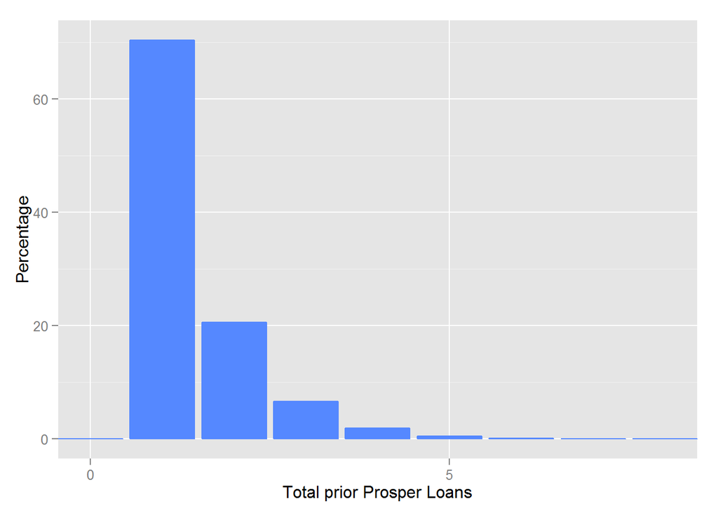

```
## Source: local data frame [10 x 2]
##
##    TotalProsperLoans     n
##                (int) (int)
## 1                  0     1
## 2                  1 15538
## 3                  2  4540
## 4                  3  1447
## 5                  4   417
## 6                  5   104
## 7                  6    29
## 8                  7     8
## 9                  8     1
## 10                NA 91852
```

There are 22084 borrowers have prior prosper loans, which account for 19%. Among them, 70% have only 1 prior prosper loans

```
## Source: local data frame [3 x 2]
##
##   prior.prosper.performance < 1     n
##                           (lgl) (int)
## 1                         FALSE 18214
## 2                          TRUE  3806
## 3                            NA 91917
```

```
##
##     FALSE      TRUE
## 0.8271571 0.1728429
```

Among 22084 borrowers who have prior prosper loans, there are 18214 borrowers pay on time (82.7%), 3806 (17.3%) borrowers have overdue

### C. Loan Activity

#### I. Loans actual performance

Loan status

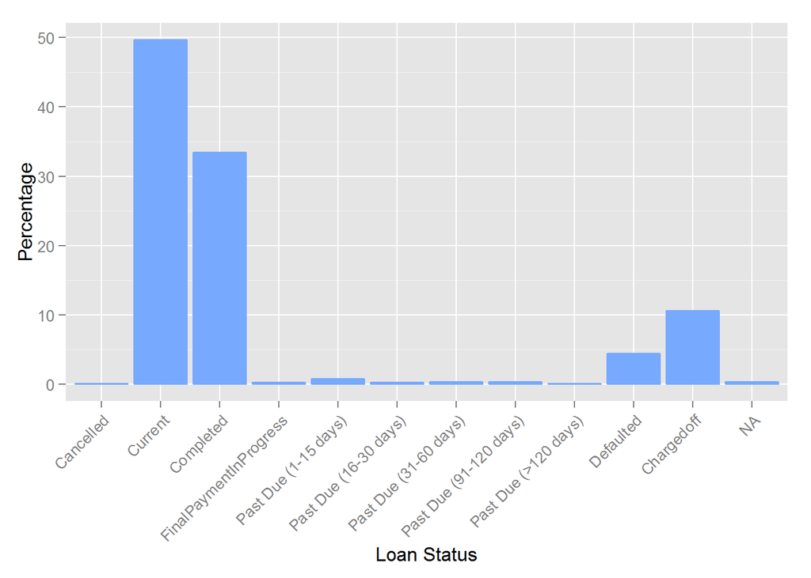

There are over 56576 Current loans (50%), over 38074 completed loans (35%) . 19077 loans have delinquent which account for 16,7% consisting of: 2067 cases deliquent from 1 to 120 days past-due, 5018 default (121+ days past due) and 11992 Chargeoff loans (150+ days past dues, no expectation of sufficient payment)

```
## [1] 16902
```

```
## [1] 0.1483451
```

Number of Gross principal Loss cases: 16902 account for 14%

#### II. Borrower rate (Interest)

```
##    Min. 1st Qu.  Median    Mean 3rd Qu.    Max.
##  0.0000  0.1340  0.1840  0.1928  0.2500  0.4975
```

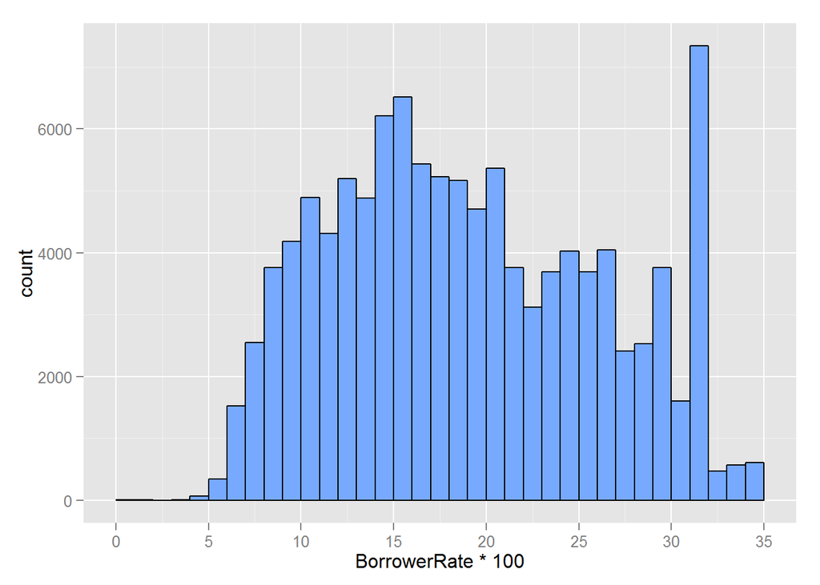

Mean interest rate is 19.28%. Haft of the rate is about 13.4% to 25%. The distribution is quite bimodal, which two modes of frequent interest rate: from 14-16% to 31-32%, which is pretty high.

Do the borrower rate diffirent with different original loan quarter? To discover this, I’ll graph the mean of borrower rate against loan origination quarter and year

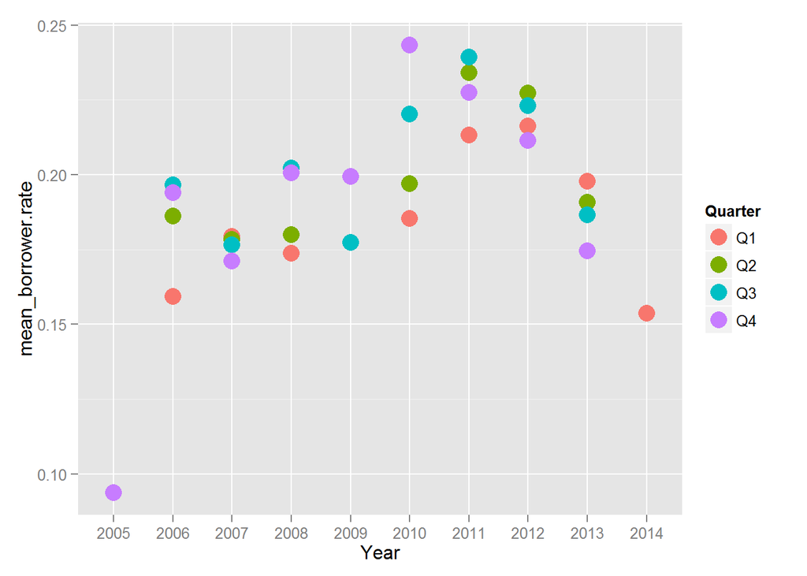

#### III. Borrower APR

Borrower APR is the Borrower’s Annual Percentage Rate (APR) for the loan. APR refers to the total cost of borrowing, as the calculation for APR includes not only the interest rate, but also many other fees the borrower might be charged. So APR is seen as the “effective interest rate,” a way for borrowers to compare one loan to another.

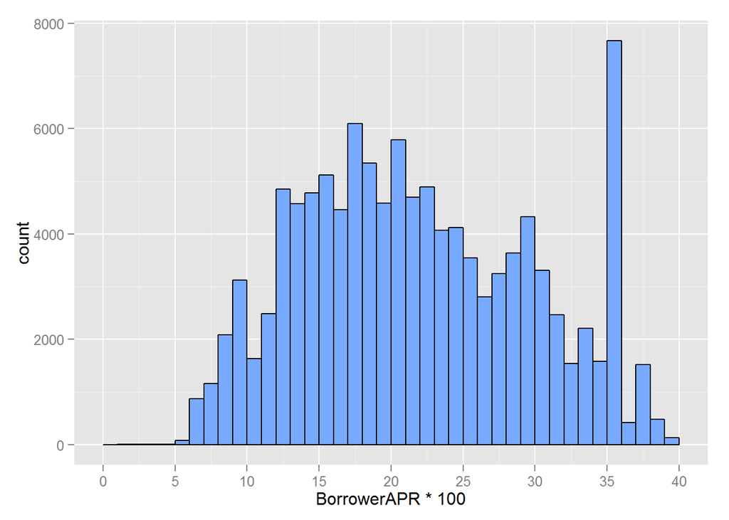

The Borrower APR distribution looks similar to that of borrower rate, although the histogram shifts rightward, indicating that the APR is generally larger than interest rate. But how large is the difference?

```
##    Min. 1st Qu.  Median    Mean 3rd Qu.    Max.    NA's
##   0.000   1.900   2.502   2.604   3.653  14.930      25
```

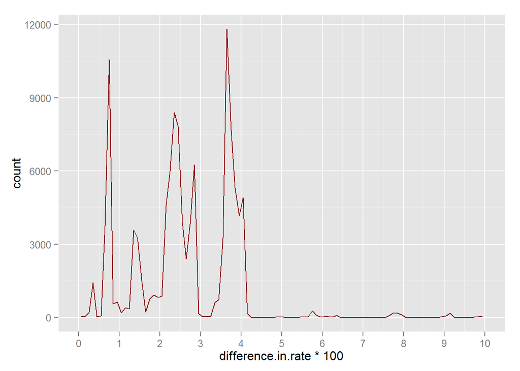

As the APR is equal to interest rate plus fees. The most common fees are around 0.5-1%, 2-3% and 3.5-4%. What cause the difference in fees?

#### IV. Investors

```
##    Min. 1st Qu.  Median    Mean 3rd Qu.    Max.
##    1.00    2.00   44.00   80.48  115.00 1189.00
```

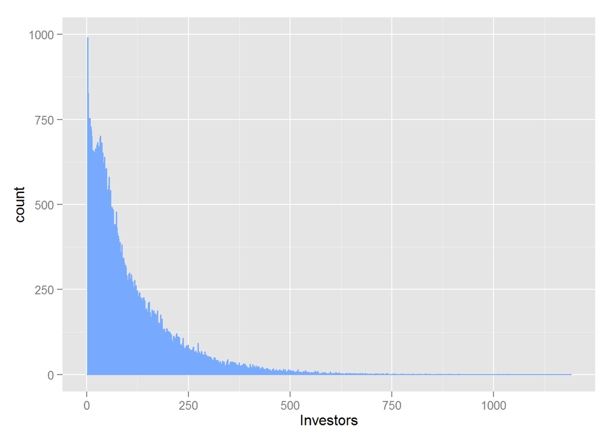

75% of loans have less than 115 investors. There are outliers, however, some loans have more than 1000 investors. I wonder what make these loans so attractive. The distribution of investor counts is right-skewed. To make it normal, I’ll transform it to log10 to reduce skewness

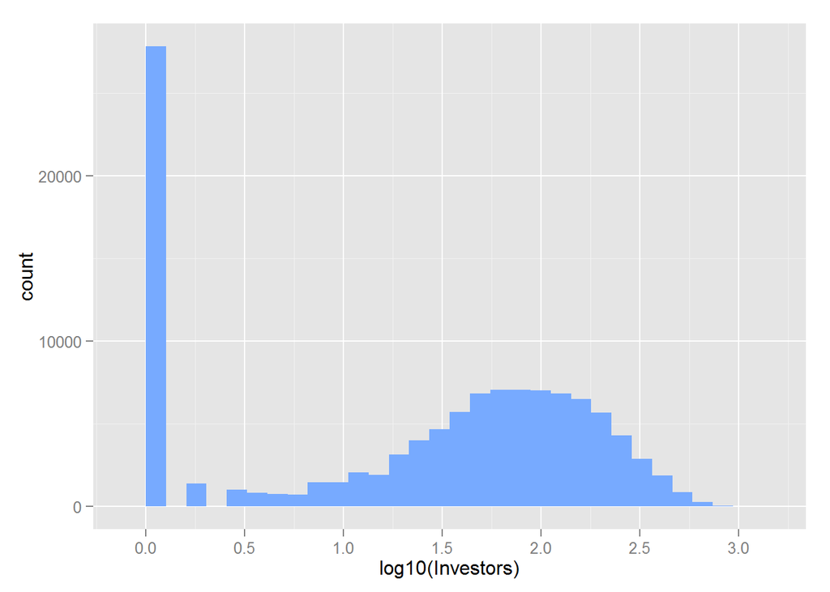

```
## Source: local data frame [2 x 2]
##
##   Investors == 1     n
##            (lgl) (int)
## 1          FALSE 86123
## 2           TRUE 27814
```

There are over 27000 loans with only 1 investors, I will cut that out of the histogram to have a better feel of investor distribution

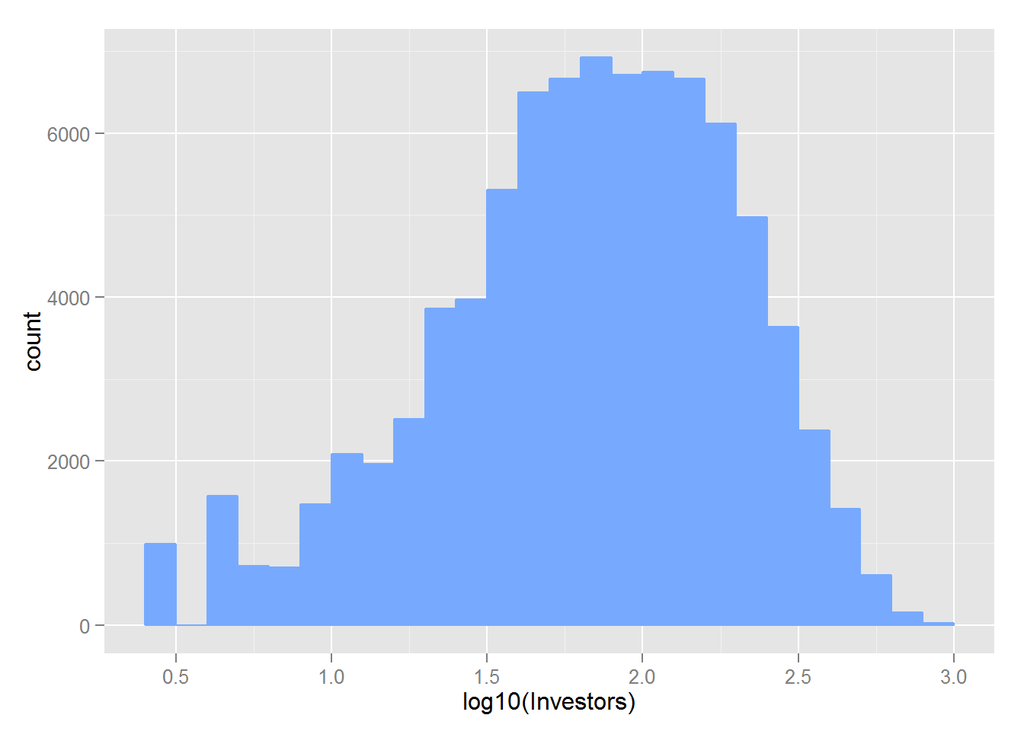

# Univariate Analysis

### What is the structure of your dataset?

This data set contains 113,937 loans with 81 variables on each loan. The variables can be classified into 3 categories: 1. Listing summary: the summary of information about the loan application based on which lenders can make investing decisions (prosper rating, loan term, loan amount, loan purpose and estimated performance of a loan such as estimated effective yield, estimated lender yield, estimated loss rate and estimated return rate) 2. Borrower’s information: borrowers’ geography, employment status and status duration, prosper score, borrower’s credit history such as credit score, prosper score, number of credit lines and current/past delinquencies… 3. The loan activity: the status of loans, number of investors, the borrower rate/APR and the loans’ performance

### What is/are the main feature(s) of interest in your dataset?

- The number of investors participate in a loan
- The interest rate (borrower rate) and APR of the loan
- The underperformed loans (charge-off loans)

### What other features in the dataset do you think will help support your investigation into your feature(s) of interest?

- What factors deciding the borrower rate and APR of a loan: prosper rating, estimated loss rate and loan term…
- What attract investors to a loan: I suspect that investor may look at prosper rating, lender yield, return yield, employment status, debt to income ratio, credit rating… to decide whether a loan is rewarding
- Common features of underperfomed loans: prosper rating, debt to income ratio, delinquencies history, proser loan history or public record…

### Did you create any new variables from existing variables in the dataset?

I created several new variables - difference.in.rate: show the difference between borrower APR and borrower rate - duration.by.bucket: join the duration of employment status duration into different intervals - rate.vs.time: group the dataset by quarter and year to compare the borrower’s rate - CreditRange: a range of lower and upper Credit Score - prior.prosper.performance: the performance of the prior prosper loan, which represent the ratio of on time payment on total billed payments. - CurrentDelinquence.bucket, Delinquence7year.bucket, Inquiries6month.bucket

### Of the features you investigated, were there any unusual distributions? Did you perform any operations on the data to tidy, adjust, or change the form of the data? If so, why did you do this?

The investor distribution is right-skewed. So I take the log10 of the number of investors to create a more normal distribution. I hope to build a regression model for this variable later.

# Bivariate and Multivariate Plots Section

## I. Prosper Rating & Estimated Loss Rate

Prosper Rating represents an estimated average annualized loss rate range to the investor. The estimated loss rate is based on the historical performance of Prosper loans with similar characteristics.

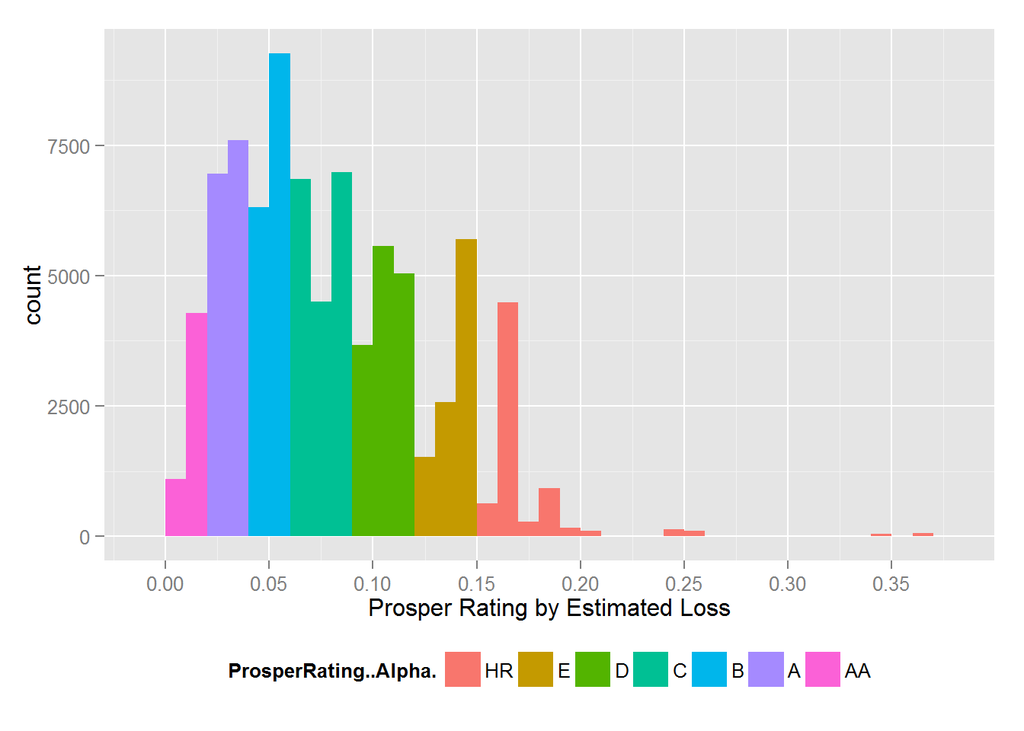

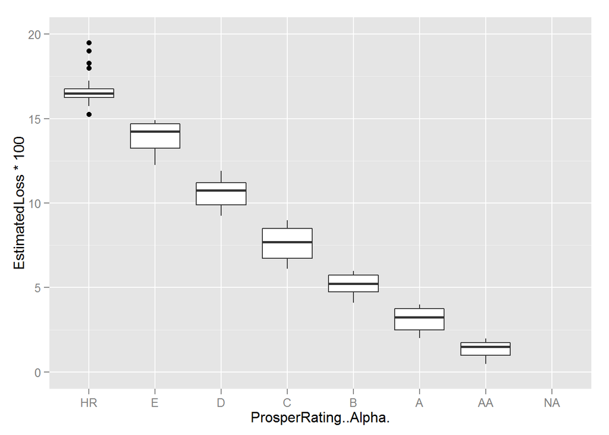

Prosper Rating vs. Estimated Avg. Annual Loss Rate

- AA 0.00 - 1.99%
- A 2.00 - 3.99%
- B 4.00 - 5.99%
- C 6.00 - 8.99%
- D 9.00 - 11.99%
- E 12.00 - 14.99%
- HR > 15.00%